# CSE-300 project

# Logistic Regression and Support Vector Machine (SVM) to classify countries based on Income Class.

- The features are scaled using StandardScaler to normalize the data, which is important for algorithms like Logistic Regression and SVM.
- Logistic Regression is a linear model suitable for classification tasks.
- SVM with an RBF kernel is a powerful algorithm that works well for non-linear classification.
- Model performance is evaluated using accuracy and classification reports.

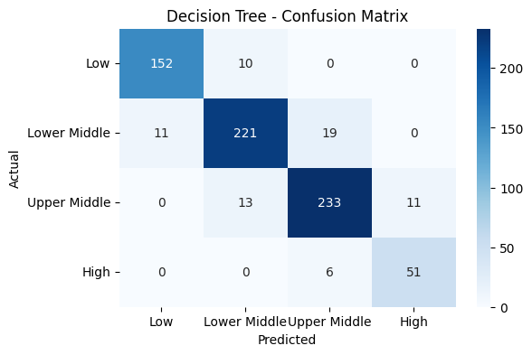

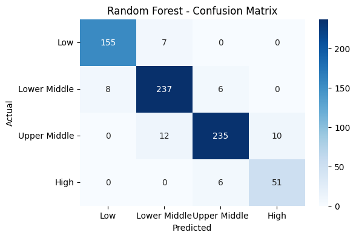

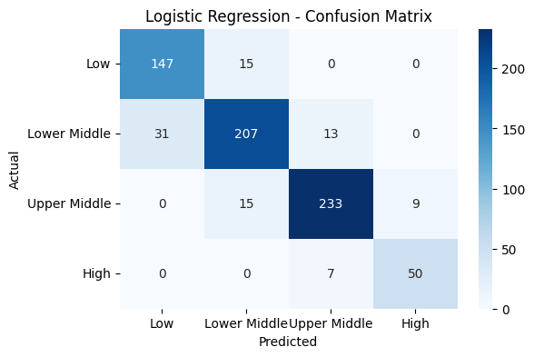

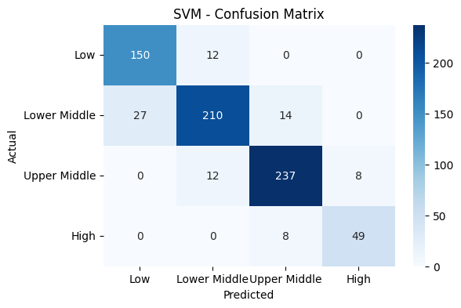

```python
import seaborn as sns
import matplotlib.pyplot as plt

def plot_confusion_matrix(y_true, y_pred, model_name):
    cm = confusion_matrix(y_true, y_pred)
    plt.figure(figsize=(6, 4))
    sns.heatmap(cm, annot=True, fmt='d', cmap='Blues',
                xticklabels=class_mapping.values(),
                yticklabels=class_mapping.values())
    plt.title(f'{model_name} - Confusion Matrix')
    plt.xlabel('Predicted')
    plt.ylabel('Actual')
    plt.show()

# Call for each model
plot_confusion_matrix(y_test, dt_predictions, "Decision Tree")
plot_confusion_matrix(y_test, rf_predictions, "Random Forest")
plot_confusion_matrix(y_test, logreg_predictions, "Logistic Regression")
plot_confusion_matrix(y_test, svm_predictions, "SVM")
```

# Confusion matrix for each classification model using a heatmap.

- It helps to understand how well the model is performing by showing the number of correct and incorrect predictions for each class.
- sns.heatmap() from Seaborn makes it easy to spot model performance visually.
- The matrix compares actual vs predicted labels for each algorithm:
  - Decision Tree
  - Random Forest
  - Logistic Regression
  - SVM

```python
from sklearn.ensemble import VotingClassifier

voting_clf = VotingClassifier(estimators=[
    ('lr', LogisticRegression(max_iter=1000)),
    ('rf', RandomForestClassifier(n_estimators=100)),
    ('svm', SVC(probability=True))
], voting='soft')

voting_clf.fit(X_train_scaled, y_train)
y_pred = voting_clf.predict(X_test_scaled)

print("Voting Classifier Accuracy:", accuracy_score(y_test, y_pred))
```

```
Voting Classifier Accuracy: 0.9202200825309491
```

# Voting Classifier, which combines multiple models to improve overall performance.

- Uses soft voting, where predicted class probabilities are averaged across models.
- Includes three base models:
  - Logistic Regression (lr)
  - Random Forest (rf)
  - Support Vector Machine (svm)
- Soft voting is useful when classifiers can output class probabilities and often gives better results than individual models.
- The final prediction is the class with the highest average probability.

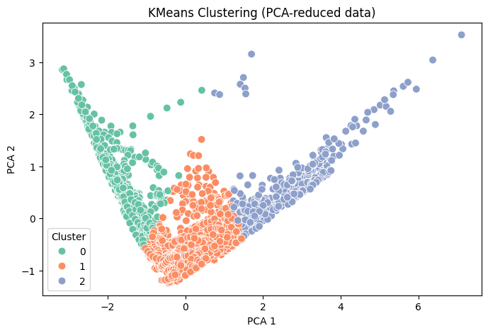

```python
from sklearn.cluster import KMeans
from sklearn.decomposition import PCA

# --- Scale the data for clustering ---
scaler = StandardScaler()
features_scaled = scaler.fit_transform(features)

# --- Apply KMeans ---
kmeans = KMeans(n_clusters=3, random_state=42)
clusters = kmeans.fit_predict(features_scaled)

# --- Visualize with PCA ---
pca = PCA(n_components=2)
pca_result = pca.fit_transform(features_scaled)

plt.figure(figsize=(8, 5))
sns.scatterplot(x=pca_result[:, 0], y=pca_result[:, 1], hue=clusters, palette='Set2', s=60)
plt.title("KMeans Clustering (PCA-reduced data)")
plt.xlabel("PCA 1")
plt.ylabel("PCA 2")
plt.legend(title='Cluster')
plt.show()
```

# KMeans Clustering Visualization – Note

- Applied KMeans clustering to group similar countries based on:
  - Child Mortality
  - Health Expenditure
  - GDP
- Used StandardScaler to normalize feature values before clustering.
- Applied PCA (Principal Component Analysis) to reduce features to 2 dimensions for easy plotting.
- Visualized the clusters using a scatter plot.
- Helps to understand natural groupings without relying on predefined income classes.

```python
from sklearn.model_selection import GridSearchCV

# Define parameter grid
param_grid = {
    'C': [0.1, 1, 10],
    'gamma': ['scale', 0.01, 0.1, 1],
    'kernel': ['rbf', 'linear']
}

# Apply GridSearch
grid = GridSearchCV(SVC(), param_grid, refit=True, verbose=1, cv=3)
grid.fit(X_train_scaled, y_train)

# Predictions & Evaluation
grid_predictions = grid.predict(X_test_scaled)
print("🔍 Best Parameters:", grid.best_params_)
print("Accuracy after tuning:", accuracy_score(y_test, grid_predictions))
print(classification_report(y_test, grid_predictions, target_names=class_mapping.values()))
```

[output not shown]

```
Fitting 3 folds for each of 24 candidates, totalling 72 fits
```

# Hyperparameter Tuning (SVM with GridSearchCV) – Note